# Measures of Dependence

A complete description of a time series, observed as a collection of $n$ random variables at arbitrary time points $t_1, t_2, \cdots, t_n$, for any positive integer $n$, is provided by the joint distribution function, evaluated as the probability that the values of the series are jointly less than the $n$ constants $c_1, c_2, \cdots, c_n$, it is,

$$ F_{t_1, \cdots, t_n}(c_1, \cdots, c_n) = Pr(X_1 \leq c_1, \cdots, X_n \leq c_n) $$

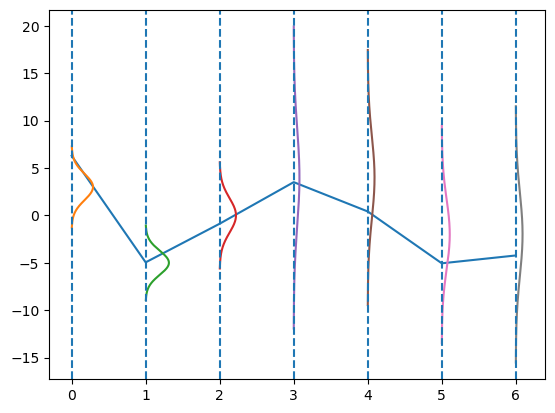

```python
ax.figure
```

Although the joint distribution function describes the data completely, it is an unwieldy tool for displaying and analyzing time series data. Anyway, the marginal distribution functions for the joint distribution function are

$$ F_t(x) = Pr(X_t \leq x) $$

or the corresponding marginal density functions

$$ f_t(x) = \frac{\partial F_f(x)}{\partial x} $$

and when they exists, are often informative for examining the marginal behavior of a series.

In practice sometimes it is difficult to get a defined joint or a marginal distribution, often we get a set of data sampled from these distributions but not the functions by themselves, so, we can use some other descriptive methods that would work theoretical and practically.

## The Expected Value

The expected value of a random variable with a finite number of outcomes is a weighted average of all possible outcomes. In the case of a continuum of possible outcomes, the expectation is defined by integration.

$$ \mu_{X_t}=\mathbb{E}[X_t] = \int_{x=-\infty}^{\infty} x f_t(x) dx $$

### Expected Value of Some Statistical Models

Excercises.

Assume that all white noises $W_i \sim \mathcal{N}(0, \sigma_W)$, and then compute

1. the expected value of the moving averages model defined by

$$ V_t=\frac{1}{3}[W_{t-1} + W_t + W_{t+1}] $$

1. the expected value of the random walk with drift model defined by

$$ X_t=\delta t + \sum_{j=1}^{t}W_j $$

## Autocovariance

The autocovariance function measures the linear dependence between two points on the same series observed at diﬀerent times, and it is defined as:

$$ \gamma_X(s,t) = \gamma_X(t, s) = \text{cov}(X_s, X_t) = \mathbb{E}[(X_s-\mu_s)(X_t-\mu_t)] $$

What is the covariance of $X_t$ with itself?

### Autocovariance of Some Statistical Models

Excercises.

Assume that all white noises $W_i \sim \mathcal{N}(0, \sigma_W)$.

1. Compute the autocovariance of white noise model

$$ \text{cov}(W_s,W_t) $$

1. Proof the equality written below of the autocovariance of a moving average model

$$ \text{cov}(V_s, V_t) = cov\left\{ \frac{1}{3}(W_{s-1} + W_s + W_{s+1}), \frac{1}{3}(W_{t-1} + W_t + W_{t+1}) \right\} = \begin{cases} \frac{3}{9} \sigma^2_W & s=t \\ \frac{2}{9} \sigma^2_W & |s-t|=1 \\ \frac{1}{9} \sigma^2_W & |s-t|=2 \\ 0 & |s-t|>0 \end{cases} $$

## Autocorrelation

The autocorrelation function measures the linear predictability of the series at time $t$, say $X_t$, using only the value at time $s$, say $X_s$, and it is defined as:

$$ \rho_X(s,t) = \frac{\gamma_X(s,t)}{\sqrt{\gamma_X(s,s) \gamma_X(t,t)}} $$

What is the correlation of $X_t$ with itself?

### Autocorrelation Bound

Excercise.

The the Cauchy-Schwarz inequality establish that given two random variables, $X$ and $Y$, with a common probability space. Then:

$$ |\mathbb{E}[XY]| \leq \sqrt{\mathbb{E}[X^2]\mathbb{E}[Y^2]} $$

Using the Cauchy-Schwarz inequality, prove that:

$$ -1 \leq \rho(s,t) \leq 1 $$

## Cross-Variance Function

Often, we would like to measure the predictability of another series $Y_t$ from the series $X_s$. Assuming both series have ﬁnite variances, we define the cross-variance function between two series, $X_s$ and $Y_t$ as

$$ \gamma_{XY}(s,t)=\text{cov}(X_s, Y_t)= \mathbb{E}[(X_s-\mu_{X_s})(Y_t-\mu_{Y_t})] $$

Why could be important to mix the analysis of two time series?

## Cross-Correlation Function

The cross-correlation function between two series, $X_s$ and $Y_t$ is given by

$$ \rho_{XY}(s,t)= \frac{\gamma_{XY}(s,t)}{\sqrt{\gamma_X(s,s) \gamma_Y(t,t)}} $$